# Data processing assignment: COVID-19

## The data

You are provided with a CSV file, `covid-19.csv` which was downloaded from the EU’s open data portal, https://data.europa.eu/euodp/en/home. This file contains data for COVID-19 cases and deaths for each country since the end of 2019.

The dates given in the first column are in the format `dd/mm/yyyy`, e.g. `16/05/2020`. These can be converted to R’s `date` datatype using the `dmy()` function from the tidyverse `lubridate` package:

```r
library(tidyverse)
library(lubridate)
dmy("16/05/2020")
```

```
[1] "2020-05-16"
```

## The tasks

0. Use the tidyverse functions to load this file into a dataframe and convert the dates from strings to the `date` datatype.

```r
df <- read_csv('covid-19.csv')
df <- df %>%
  mutate(date=dmy(dateRep))
head(df)
```

| dateRep | day | month | year | cases | deaths | countriesAndTerritories | geoId | countryterritoryCode | popData2018 | continentExp | date |
| --- | --- | --- | --- | --- | --- | --- | --- | --- | --- | --- | --- |
| 18/05/2020 | 18 | 5 | 2020 | 262 | 1 | Afghanistan | AF | AFG | 37172386 | Asia | 2020-05-18 |
| 17/05/2020 | 17 | 5 | 2020 | 0 | 0 | Afghanistan | AF | AFG | 37172386 | Asia | 2020-05-17 |
| 16/05/2020 | 16 | 5 | 2020 | 1063 | 32 | Afghanistan | AF | AFG | 37172386 | Asia | 2020-05-16 |
| 15/05/2020 | 15 | 5 | 2020 | 113 | 6 | Afghanistan | AF | AFG | 37172386 | Asia | 2020-05-15 |
| 14/05/2020 | 14 | 5 | 2020 | 259 | 3 | Afghanistan | AF | AFG | 37172386 | Asia | 2020-05-14 |
| 13/05/2020 | 13 | 5 | 2020 | 280 | 5 | Afghanistan | AF | AFG | 37172386 | Asia | 2020-05-13 |

Now create figures to show the following:

1. Daily cases for a single country.

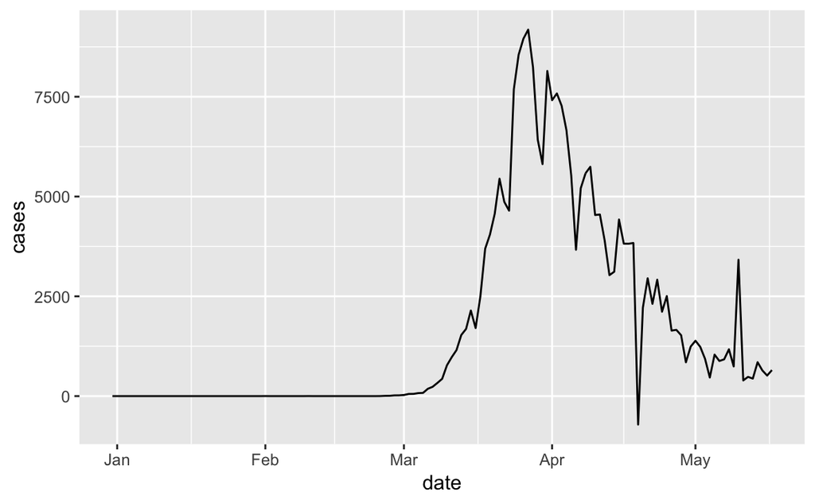

```r
df %>%
  filter(countriesAndTerritories=="Spain") %>%
  ggplot(aes(x=date,y=cases)) +
  geom_line()
```

2. Weekly cases for a single country. *Hint*: use `week()` to convert a date to a number representing the week of the year. `geom_col()` makes a bar chart from (x,y) data.

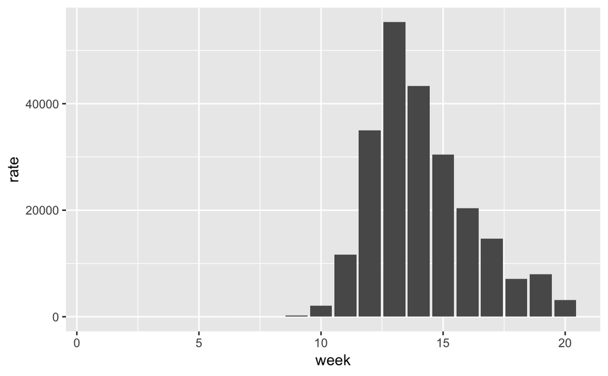

```r
df %>%
  mutate(week=week(date)) %>%
  filter(year==2020 & countriesAndTerritories=="Spain") %>%
  group_by(week) %>%
  summarise(rate = sum(cases)) %>%
  ggplot(aes(x=week,y=rate)) +
  geom_col()
```

```r
NA
```

3. Cumulative daily cases for a single country. *Hint*: use `arrange()` and `cumsum()`

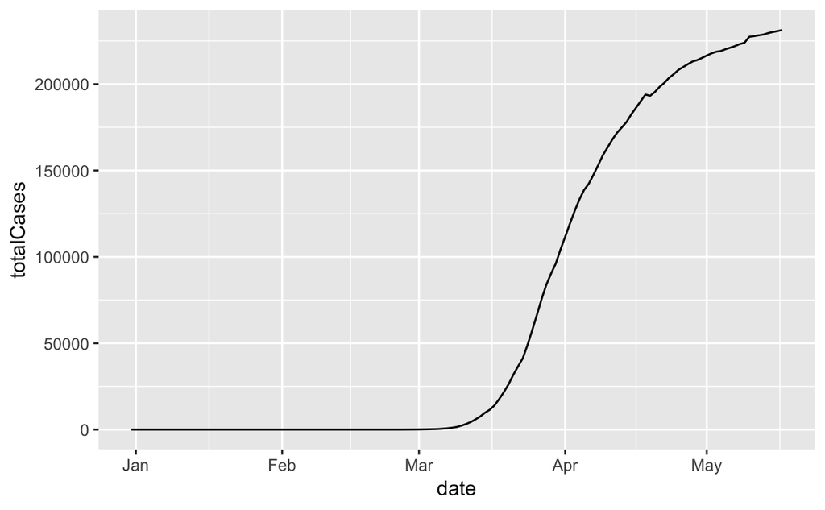

```r
df %>%
  filter(countriesAndTerritories=="Spain") %>%
  arrange(date) %>%
  mutate(totalCases = cumsum(cases)) %>%
  ggplot(aes(x=date,y=totalCases)) +
  geom_line()
```

4. Daily cases for each continent. *Hint*: use `group_by()` and `summarise()`

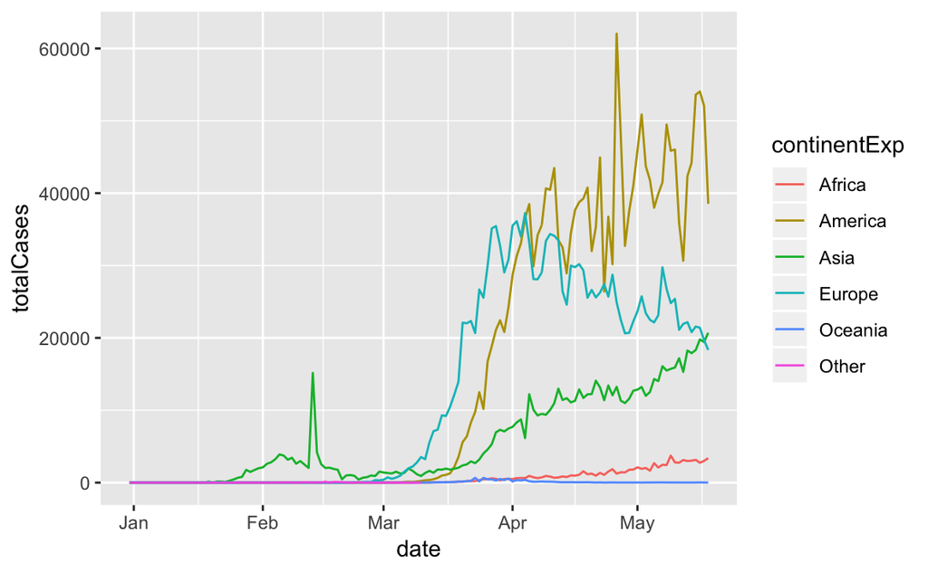

```r
df %>%
  arrange(date) %>%
  group_by(continentExp,date) %>%
  summarise(totalCases = sum(cases)) %>%
  ggplot(aes(x=date,y=totalCases, color=continentExp)) +
  geom_line()
```

5. Apparent overall mortality rate (total deaths / total cases) for each country, grouped by continent.

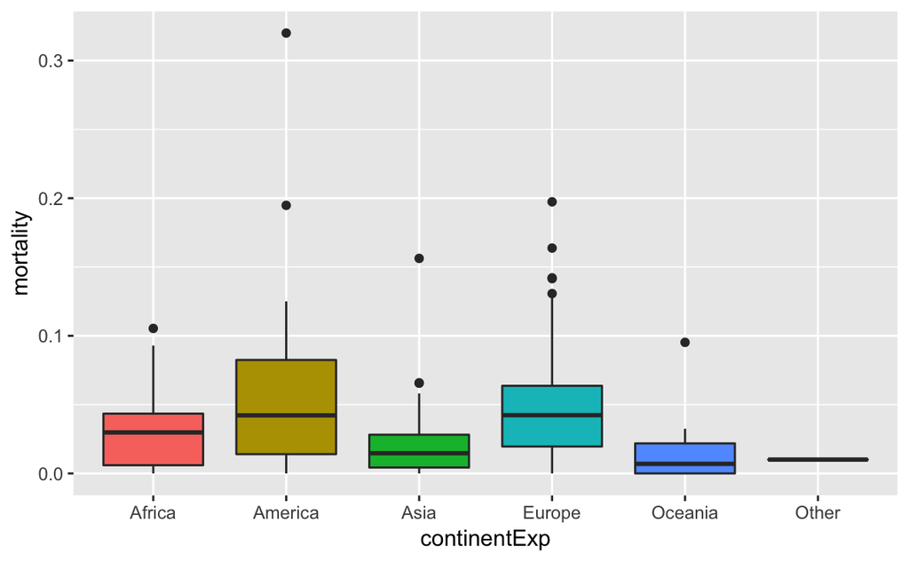

```r
df %>%
  group_by(continentExp,countriesAndTerritories) %>%
  summarise(totalDeaths = sum(deaths), totalCases = sum(cases)) %>%
  mutate(mortality = totalDeaths/totalCases) %>%
  ggplot(aes(y=mortality,x=continentExp, fill=continentExp)) +
  geom_boxplot() +
  guides(fill='none')
```

6. The UK (Referred to as “United_Kingdom” in this data set) has a strong weekly periodicity in reported COVID-19 deaths.
1. Make a plot to illustrate this effect as clearly as possible. *Hint*: `lubridate` provides a function `wday()` which returns the day of the week as an integer, starting from 1 = Sunday.

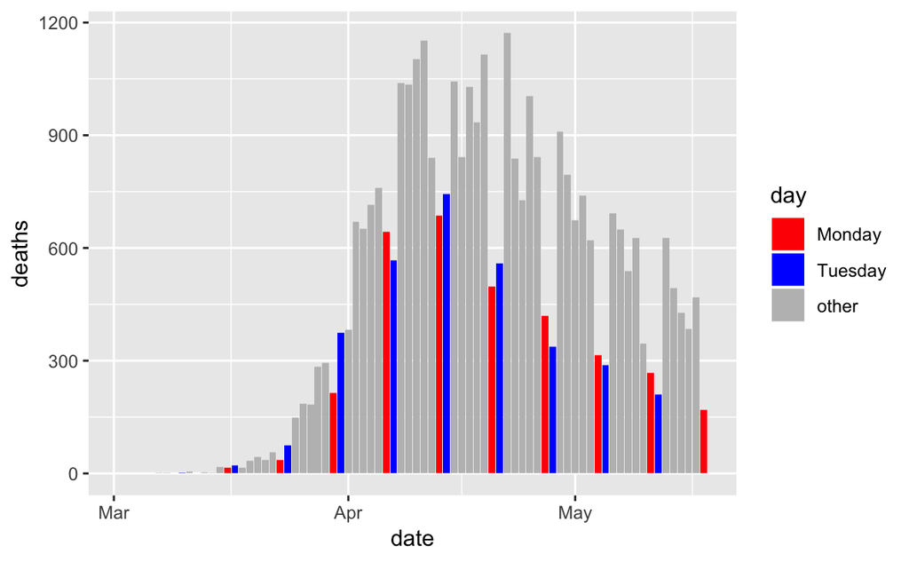

```r
daymap <- c('other','Monday','Tuesday','other','other','other','other')
df %>%
  filter(countriesAndTerritories=="United_Kingdom") %>%
  filter(date > "2020-03-01") %>%
  mutate(day = wday(date)) %>%
  mutate(day = daymap[day] ) %>%
  ggplot(aes(x=date,y=deaths, fill=day )) +
  geom_col() +
  scale_fill_manual(
    values = c('Monday'='red','Tuesday'='blue','other'='grey'),
    breaks = c('Monday','Tuesday','other')  # to order the legend
  )
```

2. Show that the number of deaths reported on Mondays and Tuesdays is significantly lower than on other days.

```r
# We can start by producing a table containing mean daily death rates for each week, grouped into (Monday+Tuesday) vs (other days).
daymap <- c('other','MonTue','MonTue','other','other','other','other')
df2 <- df %>%
  filter(countriesAndTerritories=="United_Kingdom") %>%
  mutate(week=week(date)) %>%
  mutate(day = wday(date)) %>%
  mutate(dayclass = daymap[day] ) %>%
  group_by(week, dayclass) %>%
  summarise(mean_deaths = mean(deaths))
df2
```

| week | dayclass | mean_deaths |
| --- | --- | --- |
| 1 | MonTue | 0.0 |
| 1 | other | 0.0 |
| 2 | MonTue | 0.0 |
| 2 | other | 0.0 |
| 3 | MonTue | 0.0 |
| 3 | other | 0.0 |
| 4 | MonTue | 0.0 |
| 4 | other | 0.0 |
| 5 | MonTue | 0.0 |
| 5 | other | 0.0 |

[output cut: 31 more lines]

```r
# Let's rearrange this to have the two groups in separate columns.
# We can also eliminate weeks where either rate is zero.
df3 <- df2 %>%
  spread(key = dayclass, value = mean_deaths) %>%
  filter( MonTue > 0 & other > 0)
df3
```

| week | MonTue | other |
| --- | --- | --- |
| 10 | 0.5 | 0.4 |
| 11 | 18.5 | 5.0 |
| 12 | 54.5 | 37.0 |
| 13 | 294.0 | 219.2 |
| 14 | 606.0 | 635.6 |
| 15 | 715.0 | 1033.2 |
| 16 | 528.5 | 993.0 |
| 17 | 379.0 | 916.8 |
| 18 | 301.5 | 747.6 |
| 19 | 239.0 | 570.6 |

[output cut: 1 more lines]

```r
# Owing to the overall shape of the curve, there is a dependency between
# the mean number of deaths on a (Monday+Tuesday) and the mean number of
# deaths during the week following. We should therefore use a
# paired-sample t-test to compare the values in the two columns.
# With significance level alpha=0.05:
t.test(df3$MonTue, df3$other, paired=TRUE, alternative='less' )
```

```
    Paired t-test

data:  df3$MonTue and df3$other
t = -3.0719, df = 10, p-value = 0.005902
alternative hypothesis: true difference in means is less than 0
95 percent confidence interval:
      -Inf -86.91925
sample estimates:
mean of the differences
              -212.0091
```

```r
# The resulting p < alpha, so we can reject the null hypothesis that the group
# (Monday+Tuesday) have the same mean as the other days.
```

3. Do any other countries show a similar periodicity?

```r
# We can use `map_dbl()` to apply the same hypothesis test to all countries:
daymap <- c('other','MonTue','MonTue','other','other','other','other')
do_test <- function(c) {

  dfx <- df %>%
    filter(countriesAndTerritories==c) %>%
    mutate(week=week(date)) %>%
    mutate(day = wday(date)) %>%
    mutate(dayclass = daymap[day] ) %>%
    group_by(week, dayclass) %>%
    summarise(mean_deaths = mean(deaths)) %>%
    spread(key = dayclass, value = mean_deaths) %>%
    filter( MonTue > 0 & other > 0)

  # Before attempting the t-test, check that
  if( 'MonTue' %in% names(dfx) &       # both groups are present
      'other' %in% names(dfx) &
      nrow(dfx) > 1 &                  # there is more than one week
      ( var(dfx$MonTue) > 0 |          # there is some variation
      var(dfx$other) > 0 )
  ) {
    return( t.test(dfx$MonTue, dfx$other,
                   paired=TRUE,
                   alternative='less'
                   )$p.value )
  }
  else return( NA )

}
all_countries <- df %>%
  filter(deaths > 0) %>%
  pull(countriesAndTerritories) %>%
  sort %>%
  unique
pval <- map_dbl(all_countries, do_test)  # do the tests
names(pval) <- all_countries  # add the country names
pval <- pval[!is.na(pval)]    # remove the countries that couldn't be tested.
pval <- sort(pval)            # sort by ascending p-value
pval[pval< 0.01]             # show the countries with lowest p-value
```

```
   Switzerland United_Kingdom         Sweden    Netherlands
   0.002472689    0.005901682    0.006473377    0.009478236
```

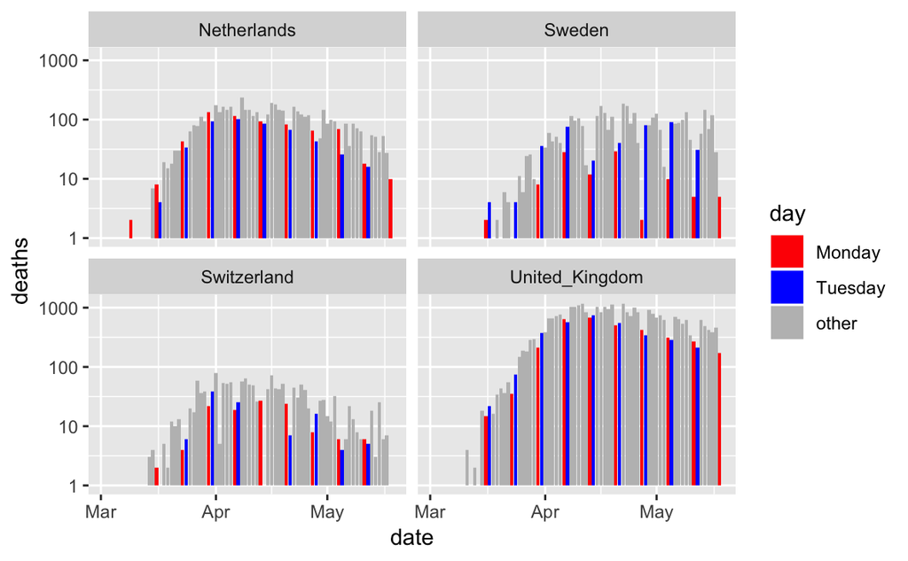

```r
# Although we haven't corrected for multiple hypothesis testing,
# these p-values do appear low enough to be interesting.
# Let's visualise these distributions:
country_list <- names(pval[pval< 0.01])
daymap <- c('other','Monday','Tuesday','other','other','other','other')
df %>%
  filter(countriesAndTerritories %in% country_list) %>%
  filter(date > "2020-03-01") %>%
  mutate(day = wday(date)) %>%
  mutate(day = daymap[day] ) %>%
  ggplot(aes(x=date,y=deaths, fill=day )) +
  geom_col() +
  scale_y_log10() +
  facet_wrap(vars(countriesAndTerritories)) +
  scale_fill_manual(
    values = c('Monday'='red','Tuesday'='blue','other'='grey'),
    breaks = c('Monday','Tuesday','other')  # to order the legend
  )
```

```r
# We haven't proven anything statistically, but it does seem that other
# countries experience a similar phenomenon.
```

4. How could you explain what is happening, and what are the implications for how we use the data?

```r
# One possible explanation is that there is an administrative backlog
# after the weekend (for example, relatives need to be notified before a
# death can be officially reported). This could lead to a reduction in reported
# deaths early in the week.
#
# The main implication in making use of the data is that it makes no sense to
# compare figures day-by-day, only week-by-week.
#
# You can find more discussion of this sort of periodic effect at
# https://twitter.com/jburnmurdoch/status/1247681939575910402
# and
# https://jmuccigr.github.io/blog/2020/04/10/Weekly-Periodicity/
```